# Homework 5 DATA3421

LeMaur Kydd

2023-03-08

```r
library(plyr)
library(readr)
library(ggplot2)
library(ggcorrplot)
library(dplyr)
library(psych)
```

## *Data Visualization*

#### 1.Load the iris dataset into R and explore its structure and summary statistics.

```r
library(datasets)
data(iris)
summary(iris)
```

```
##   Sepal.Length    Sepal.Width     Petal.Length    Petal.Width
##  Min.   :4.300   Min.   :2.000   Min.   :1.000   Min.   :0.100
##  1st Qu.:5.100   1st Qu.:2.800   1st Qu.:1.600   1st Qu.:0.300
##  Median :5.800   Median :3.000   Median :4.350   Median :1.300
##  Mean   :5.843   Mean   :3.057   Mean   :3.758   Mean   :1.199
##  3rd Qu.:6.400   3rd Qu.:3.300   3rd Qu.:5.100   3rd Qu.:1.800
##  Max.   :7.900   Max.   :4.400   Max.   :6.900   Max.   :2.500
##        Species
##  setosa    :50
##  versicolor:50
##  virginica :50
##
##
##
```

```r
dim(iris)
```

```
## [1] 150   5
```

#### 2.Create a scatterplot of the sepal length and width of the iris flowers. Use different colors to represent the different species of flowers.

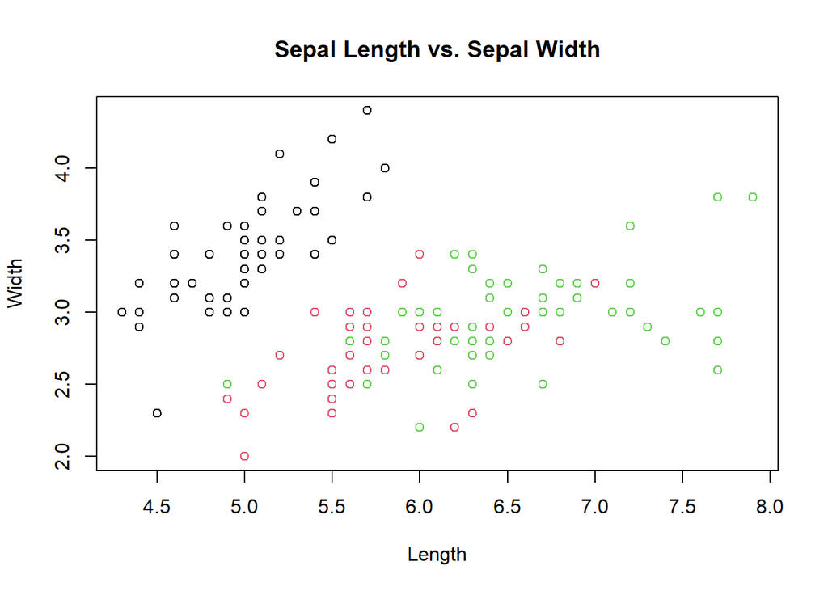

```r
plot(iris$Sepal.Length, iris$Sepal.Width,
     main='Sepal Length vs. Sepal Width',
     xlab='Length',
     ylab='Width',
     col=iris$Species)
```

#### 3.Create a boxplot of the petal length for each species of flower.

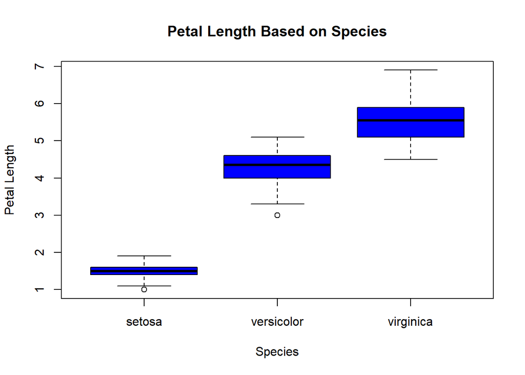

```r
boxplot(iris$Petal.Length ~ iris$Species,
        xlab='Species',
        ylab='Petal Length',
        main='Petal Length Based on Species',
        col='blue')
```

#### 4.Create a histogram of the sepal width of the iris flowers.

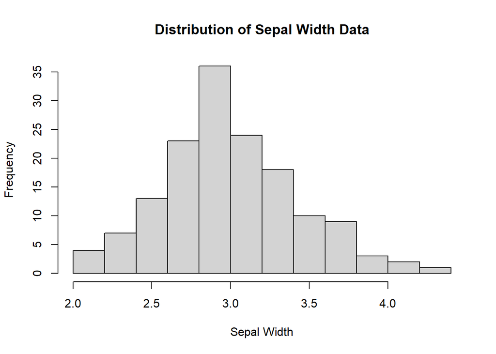

```r
hist(iris$Sepal.Width,
     xlab='Sepal Width',
     main='Distribution of Sepal Width Data')
```

## *Linear Regression*

#### 1.Load the mtcars dataset into R and explore its structure and summary statistics.

```r
data(mtcars)
summary(mtcars)
```

```
##       mpg             cyl             disp             hp
##  Min.   :10.40   Min.   :4.000   Min.   : 71.1   Min.   : 52.0
##  1st Qu.:15.43   1st Qu.:4.000   1st Qu.:120.8   1st Qu.: 96.5
##  Median :19.20   Median :6.000   Median :196.3   Median :123.0
##  Mean   :20.09   Mean   :6.188   Mean   :230.7   Mean   :146.7
##  3rd Qu.:22.80   3rd Qu.:8.000   3rd Qu.:326.0   3rd Qu.:180.0
##  Max.   :33.90   Max.   :8.000   Max.   :472.0   Max.   :335.0
##       drat             wt             qsec             vs
##  Min.   :2.760   Min.   :1.513   Min.   :14.50   Min.   :0.0000
##  1st Qu.:3.080   1st Qu.:2.581   1st Qu.:16.89   1st Qu.:0.0000
##  Median :3.695   Median :3.325   Median :17.71   Median :0.0000
##  Mean   :3.597   Mean   :3.217   Mean   :17.85   Mean   :0.4375
##  3rd Qu.:3.920   3rd Qu.:3.610   3rd Qu.:18.90   3rd Qu.:1.0000
##  Max.   :4.930   Max.   :5.424   Max.   :22.90   Max.   :1.0000
##        am              gear            carb
##  Min.   :0.0000   Min.   :3.000   Min.   :1.000
##  1st Qu.:0.0000   1st Qu.:3.000   1st Qu.:2.000
##  Median :0.0000   Median :4.000   Median :2.000
##  Mean   :0.4062   Mean   :3.688   Mean   :2.812
##  3rd Qu.:1.0000   3rd Qu.:4.000   3rd Qu.:4.000
##  Max.   :1.0000   Max.   :5.000   Max.   :8.000
```

```r
dim(mtcars)
```

```
## [1] 32 11
```

#### 2.Use linear regression to model the relationship between “mpg” (dependent variable) and “hp” (Independent variable). Interpret the regression coefficients and R-squared value.

```r
relation <- lm(mtcars$mpg ~ mtcars$hp)
summary(relation)
```

```
##
## Call:
## lm(formula = mtcars$mpg ~ mtcars$hp)
##
## Residuals:
##     Min      1Q  Median      3Q     Max
## -5.7121 -2.1122 -0.8854  1.5819  8.2360
##
## Coefficients:
##             Estimate Std. Error t value Pr(>|t|)
## (Intercept) 30.09886    1.63392  18.421  < 2e-16 ***
## mtcars$hp   -0.06823    0.01012  -6.742 1.79e-07 ***
## ---
## Signif. codes:  0 '***' 0.001 '**' 0.01 '*' 0.05 '.' 0.1 ' ' 1
##
## Residual standard error: 3.863 on 30 degrees of freedom
## Multiple R-squared:  0.6024, Adjusted R-squared:  0.5892
## F-statistic: 45.46 on 1 and 30 DF,  p-value: 1.788e-07
```

**Explanation:** The regression slope is -0.07 meaning that for every 1 horse power increased, you will lose 0.07 mpg. The intercept is 30.1, meaning that for this dataset, we begin our decline from about 30 miles per gallon. The r-squared value is about 0.6, meaning 60% of the variation in mpg is explained by the horse power variable.

#### 3.Create a multiple linear regression model (using “hp” and “wt” as Independent variables, and mpg as a dependent variable).

```r
relation1 <- lm(mtcars$mpg ~ mtcars$hp + mtcars$wt)
summary(relation1)
```

```
##
## Call:
## lm(formula = mtcars$mpg ~ mtcars$hp + mtcars$wt)
##
## Residuals:
##    Min     1Q Median     3Q    Max
## -3.941 -1.600 -0.182  1.050  5.854
##
## Coefficients:
##             Estimate Std. Error t value Pr(>|t|)
## (Intercept) 37.22727    1.59879  23.285  < 2e-16 ***
## mtcars$hp   -0.03177    0.00903  -3.519  0.00145 **
## mtcars$wt   -3.87783    0.63273  -6.129 1.12e-06 ***
## ---
## Signif. codes:  0 '***' 0.001 '**' 0.01 '*' 0.05 '.' 0.1 ' ' 1
##
## Residual standard error: 2.593 on 29 degrees of freedom
## Multiple R-squared:  0.8268, Adjusted R-squared:  0.8148
## F-statistic: 69.21 on 2 and 29 DF,  p-value: 9.109e-12
```

#### 4.Compare the predictive power of the simple linear regression model (using “hp” as the predictor variable) and the multiple linear regression model (using “hp” and “wt” as predictor variables).

```r
anova(relation, relation1)
```

```
## Analysis of Variance Table
##
## Model 1: mtcars$mpg ~ mtcars$hp
## Model 2: mtcars$mpg ~ mtcars$hp + mtcars$wt
##   Res.Df    RSS Df Sum of Sq      F   Pr(>F)
## 1     30 447.67
## 2     29 195.05  1    252.63 37.561 1.12e-06 ***
## ---
## Signif. codes:  0 '***' 0.001 '**' 0.01 '*' 0.05 '.' 0.1 ' ' 1
```

**Explanation:** The P-value of the ANOVA test is significantly lower than our assumed 0.05 alpha value, meaning there is a statistically significant difference between the power of the simple linear regression model and the multiple linear regression model.